# Tool comparison

Comparison of BARtab bulk ref-free workflow on DNA-seq (barcode-seq) data from Goyal et al. 2023.

Upstream scripts: `bartab_yogesh.sbatch`, `pycashier_yogesh.sbatch`, `timemachine_yogesh.sbatch`, `timemachine_yogesh_umis.sbatch`

Data to compare: - published results based on UMI counts - timemachine re-analysis based on read counts - timemachine re-analysis based on UMI counts - BARtab re-ananlysis - pycashier re-analysis

Metrics to compare: - detected barcodes - pearson and spearman correlation of barcode quantification per sample

Steps 1. Read in all data 2. Collapse replicates for BARtab and pycashier by mean 3. Detected barcode overlap between published data and timemachine re-analysis 4. Detected barcode overlap between pycashier, BARtab, timemachine at different filtering thresholds 5. Calculate pearson and spearman correlation of barcode quantification for all samples 6. Visualize correlation of barcode quantification 7. Visualize correlation of UMI and read count quantification

(Published barcode quantification from Goyal 2023 is referred to as `yogesh`.)

```r
library(tidyverse)
```

```r
library(ggplot2)
library(ggvenn)
library(bartools)
plots.dir <- "/dawson_genomics/Projects/bartools_bartab_paper/results/yogesh_comparison/plots/"
results.dir <- "/dawson_genomics/Projects/bartools_bartab_paper/results/yogesh_comparison/"
```

## Load data

Sample sheet for published Yogesh data, re-analysis with timemachine and BARtab.

Sample sheet contains paths to count files and which samples are replicates.

```r
samplesheet <-
  readxl::read_excel(
    "/dawson_genomics/Projects/bartools_bartab_paper/scripts/yogesh_comparison/yogesh_comparison_samplesheet.xlsx"
  )
samplesheet <- as.data.frame(samplesheet)
rownames(samplesheet) <- samplesheet$sample
# samplesheet
```

Read in BARtab and timemachine results and published data into DGEList objects.

```r
# read in BARtab results
samplesheet$files <- samplesheet$bartab_files
bartab_results <-
  edgeR::readDGE(
    files = samplesheet,
    labels = samplesheet$sample,
    group = samplesheet$group,
    header = F
  )

# read in published results from Yogesh paper
samplesheet_y <- samplesheet %>%
  select(group, yogesh_files) %>%
  unique()
samplesheet_y$files <- samplesheet_y$yogesh_files
yogesh_results <-
  edgeR::readDGE(
    files = samplesheet_y,
    labels = samplesheet_y$group,
    group = samplesheet_y$group,
    header = F
  )


# read in data re-analyzed with timemachine (read counts)
samplesheet_t <- samplesheet %>%
  select(group, timemachine_files) %>%
  unique()
samplesheet_t$files <- samplesheet_t$timemachine_files
timemachine_reads_results <-
  edgeR::readDGE(
    files = samplesheet_t,
    labels = samplesheet_t$group,
    group = samplesheet_t$group,
    header = F
  )

# read in data re-analyzed with timemachine (umi counts)
samplesheet_t$files <- gsub("Reads", "UMIs", samplesheet_t$files)
timemachine_umis_results <-
  edgeR::readDGE(
    files = samplesheet_t,
    labels = samplesheet_t$group,
    group = samplesheet_t$group,
    header = F
  )
```

Load pycashier results from combined table.

```r
pycashier_counts <-
  "/dawson_genomics/Projects/bartools_bartab_paper/results/yogesh_comparison/pycashier_results_all_samples_d8/combined.tsv"
pycashier_counts <- read.delim(pycashier_counts)

pycashier_counts <- pycashier_counts %>%
  pivot_wider(id_cols = sequence,
              values_from = count,
              names_from = sample)

pycashier_counts[is.na(pycashier_counts)] <- 0
pycashier_counts <- as.data.frame(pycashier_counts)
rownames(pycashier_counts) <- pycashier_counts$sequence
pycashier_counts$sequence <- NULL

pycashier_results <-
  edgeR::DGEList(
    pycashier_counts,
    samples = colnames(pycashier_counts),
    group = gsub(
      pattern = "_S.*",
      replacement = "",
      colnames(pycashier_counts)
    )
  )
```

## Preprocess BARtab results

Check correlation between replicates to see whether samples should be collapsed by sum or mean.

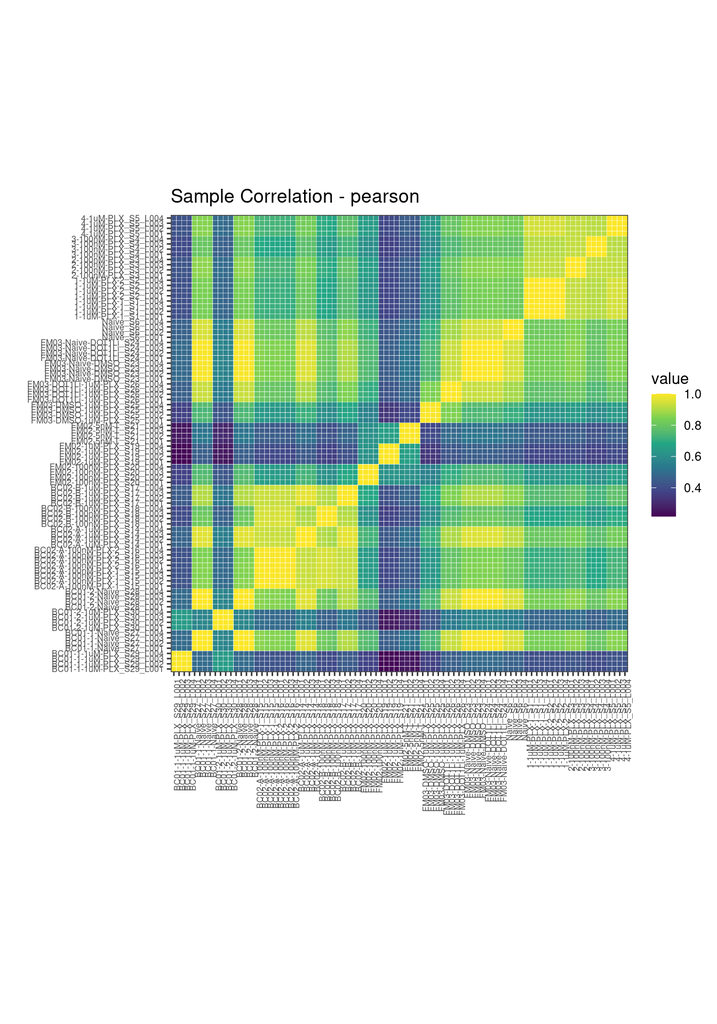

```r
plotBarcodeCorrelation(bartab_results, clustered = F, upper = F)
```

Good correlation between replicates, no undersampling, thus collapsing replicates with `mean`.

```r
bartab_results_collapsed <-
  bartools::collapseReplicates(bartab_results,
                               method = "mean",
                               group = "group")
```

## Preprocess pycashier results

Collapse replicates with `mean`.

```r
pycashier_results_collapsed <-
  bartools::collapseReplicates(pycashier_results,
                               method = "mean",
                               group = "group")
```

Order samples in dataframes in the same way

```r
pycashier_results_collapsed <- pycashier_results_collapsed[,colnames(bartab_results_collapsed)]
```

## Comparison with timemachine

Order samples in dataframes in the same way

```r
yogesh_results <- yogesh_results[,colnames(bartab_results_collapsed)]
timemachine_reads_results <- timemachine_reads_results[,colnames(bartab_results_collapsed)]
timemachine_umis_results <- timemachine_umis_results[,colnames(bartab_results_collapsed)]
```

### Barcode length

Percentage of barcodes and barcode reads that are not 100bp long

```r
paste(
  sum(str_length(rownames(timemachine_reads_results)) != 100) / nrow(timemachine_reads_results),
  sum(timemachine_reads_results$counts[str_length(rownames(timemachine_reads_results)) != 100, ]) / sum(timemachine_reads_results$counts)
)
```

```
## [1] "0.116914381410927 0.0993061152240428"
```

```r
paste(
  sum(str_length(rownames(bartab_results)) != 100) / nrow(bartab_results),
  sum(bartab_results$counts[str_length(rownames(bartab_results)) != 100, ]) / sum(bartab_results$counts)
)
```

```
## [1] "0.119298195029122 0.100474781789953"
```

```r
paste(
  sum(str_length(rownames(pycashier_results)) != 100) / nrow(pycashier_results),
  sum(pycashier_results$counts[str_length(rownames(pycashier_results)) != 100, ]) / sum(pycashier_results$counts)
)
```

```
## [1] "0.105804558162683 0.0914206206177239"
```

```r
paste(max(str_length(rownames(timemachine_reads_results))), min(str_length(rownames(timemachine_reads_results))))
```

```
## [1] "109 40"
```

```r
paste(max(str_length(rownames(bartab_results))), min(str_length(rownames(bartab_results))))
```

```
## [1] "124 40"
```

```r
paste(max(str_length(rownames(pycashier_results))), min(str_length(rownames(pycashier_results))))
```

```
## [1] "108 92"
```

Barcode lengths vary between 109 and 40 for timemachine, between 124 and 40 for BARtab and between 108 and 92 for pycashier.

### Venn diagrams

```r
x <- list(
  pycashier = rownames(pycashier_results),
  yogesh = rownames(yogesh_results),
  timemachine_umis = rownames(timemachine_umis_results),
  timemachine_reads = rownames(timemachine_reads_results),
  bartab = rownames(bartab_results)
  )
```

1. Could we reproduce published results?
2. What is the overlap between tools?

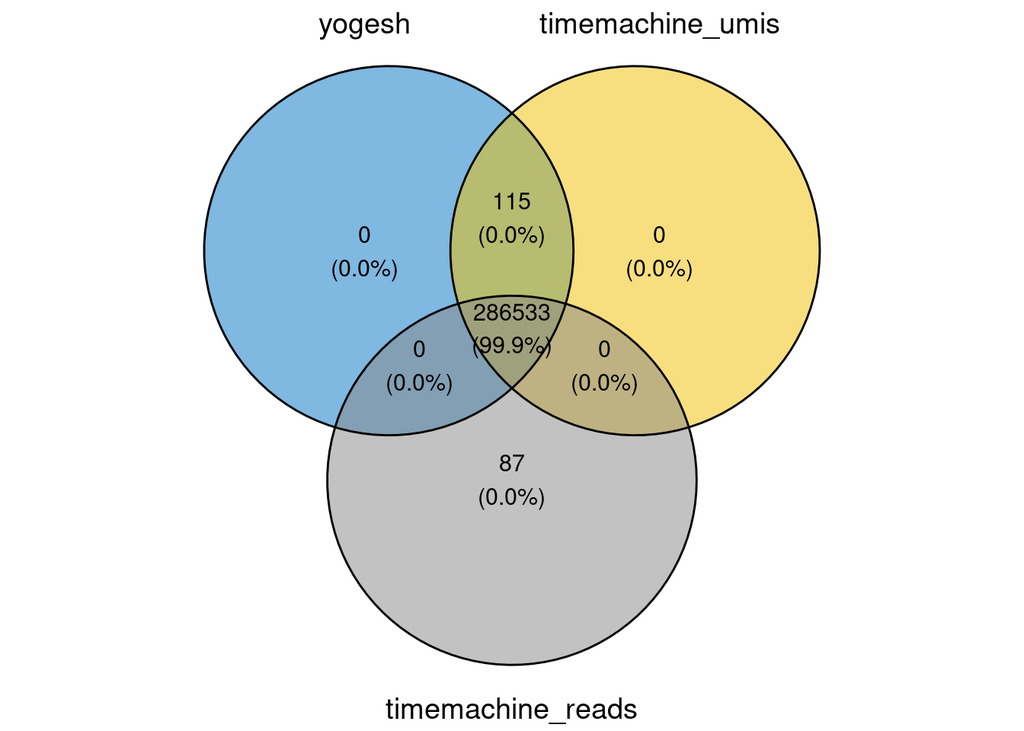

```r
ggvenn(
  x, columns = c("yogesh", "timemachine_umis", "timemachine_reads"),
  fill_color = c("#0073C2FF", "#EFC000FF", "#868686FF"),
  stroke_size = 0.5, set_name_size = 5
  )
```

```r
ggsave(file.path(plots.dir, "venn_yogesh_timemachine_reads_umis.pdf"))
```

Filter barcodes within each sample that are below percentage threshold

```r
filterBarcodesPerSample <- function(counts, filterCutoff = 0.1) {
  # transform barcode quantification into percentage within sample
  barcodes.proportional <-
    sweep(counts,
          2,
          colSums(counts),
          `/`) * 100

  # set all barcodes below threshold to 0
  barcodes.proportional[barcodes.proportional < filterCutoff] <- 0

  # remove all barcodes that are 0 across all samples (not detected)
  barcodes.proportional <-
    barcodes.proportional[rowSums(barcodes.proportional) != 0, ]

  return(barcodes.proportional)
}
```

Filter barcodes at different thresholds for timemachine (read counts), pycashier and BARtab results.

```r
x_filtered_.1 <- list(
  pycashier = rownames(
    filterBarcodesPerSample(pycashier_results_collapsed$counts, 0.1)
  ),
  yogesh = rownames(filterBarcodesPerSample(yogesh_results$counts, 0.1)),
  timemachine_umis = rownames(
    filterBarcodesPerSample(timemachine_umis_results$counts, 0.1)
  ),
  timemachine_reads = rownames(
    filterBarcodesPerSample(timemachine_reads_results$counts, 0.1)
  ),
  bartab = rownames(
    filterBarcodesPerSample(bartab_results_collapsed$counts, 0.1)
  )
)

x_filtered_.01 <- list(
  pycashier = rownames(
    filterBarcodesPerSample(pycashier_results_collapsed$counts, 0.01)
  ),
  yogesh = rownames(filterBarcodesPerSample(yogesh_results$counts, 0.01)),
  timemachine_umis = rownames(
    filterBarcodesPerSample(timemachine_umis_results$counts, 0.01)
  ),
  timemachine_reads = rownames(
    filterBarcodesPerSample(timemachine_reads_results$counts, 0.01)
  ),
  bartab = rownames(
    filterBarcodesPerSample(bartab_results_collapsed$counts, 0.01)
  )
)

x_filtered_.001 <- list(
  pycashier = rownames(
    filterBarcodesPerSample(pycashier_results_collapsed$counts, 0.001)
  ),
  yogesh = rownames(filterBarcodesPerSample(yogesh_results$counts, 0.001)),
  timemachine_umis = rownames(
    filterBarcodesPerSample(timemachine_umis_results$counts, 0.001)
  ),
  timemachine_reads = rownames(
    filterBarcodesPerSample(timemachine_reads_results$counts, 0.001)
  ),
  bartab = rownames(
    filterBarcodesPerSample(bartab_results_collapsed$counts, 0.001)
  )
)

x_filtered_.0001 <- list(
  pycashier = rownames(
    filterBarcodesPerSample(pycashier_results_collapsed$counts, 0.0001)
  ),
  yogesh = rownames(filterBarcodesPerSample(yogesh_results$counts, 0.0001)),
  timemachine_umis = rownames(
    filterBarcodesPerSample(timemachine_umis_results$counts, 0.0001)
  ),
  timemachine_reads = rownames(
    filterBarcodesPerSample(timemachine_reads_results$counts, 0.0001)
  ),
  bartab = rownames(
    filterBarcodesPerSample(bartab_results_collapsed$counts, 0.0001)
  )
)
```

Create Venn diagrams of overlap of detected barcodes for different thresholds and no filtering.

```r
ggvenn(
  x_filtered_.1,
  columns = c("pycashier", "bartab", "timemachine_reads"),
  fill_color = c("#CD534CFF", "#1AA11DC1", "#868686FF"),
  stroke_size = 0.5,
  set_name_size = 5
)
```

[figure not shown]

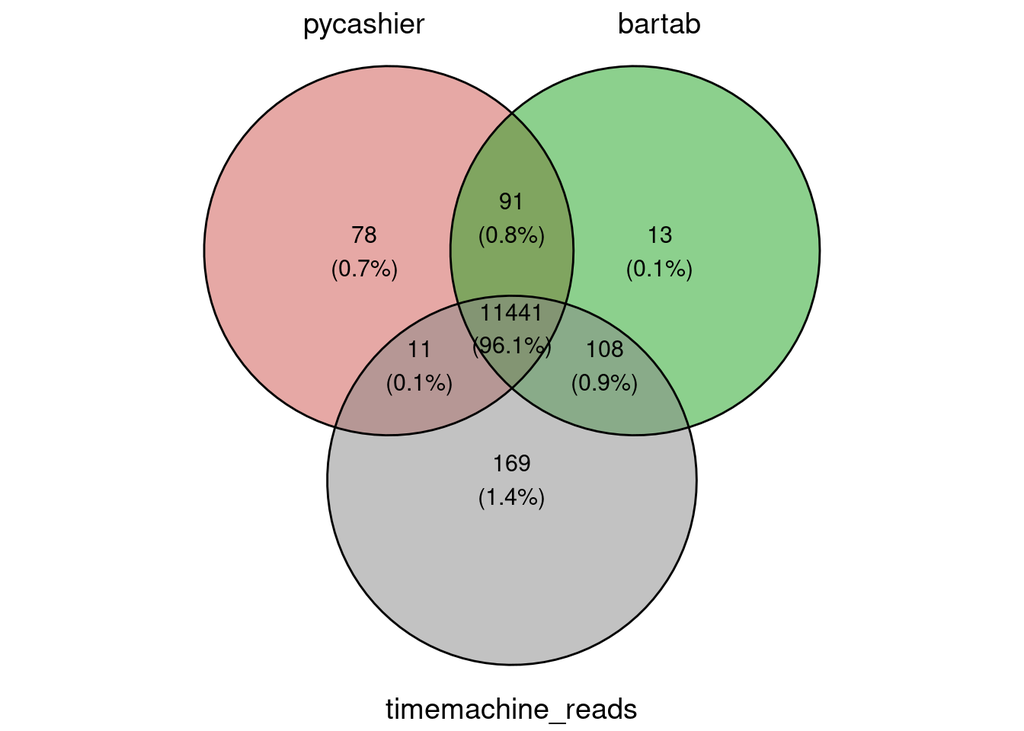

```r
ggsave(file.path(
  plots.dir,
  "venn_timemachine_reads_bartab_pycashier_0.1p.pdf"
))
ggvenn(
  x_filtered_.01,
  columns = c("pycashier", "bartab", "timemachine_reads"),
  fill_color = c("#CD534CFF", "#1AA11DC1", "#868686FF"),
  stroke_size = 0.5,
  set_name_size = 5
)
```

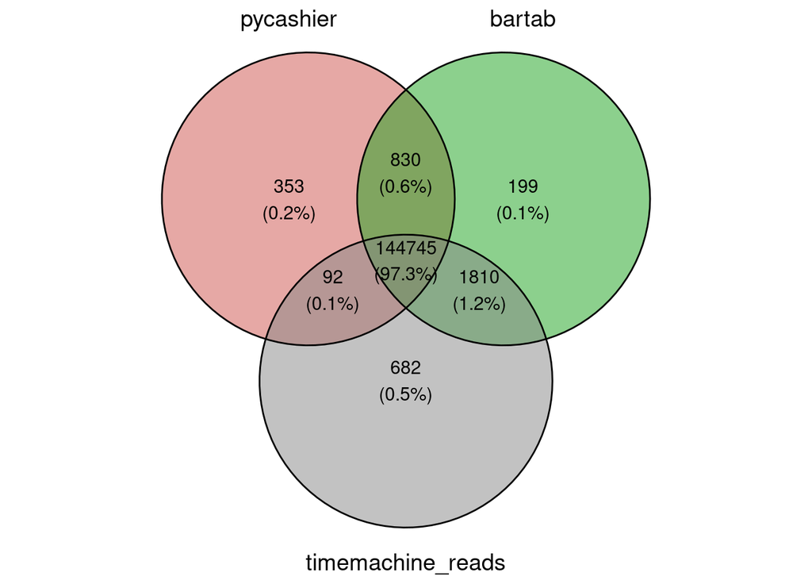

```r
ggsave(file.path(
  plots.dir,
  "venn_timemachine_reads_bartab_pycashier_0.01p.pdf"
))
ggvenn(
  x_filtered_.001,
  columns = c("pycashier", "bartab", "timemachine_reads"),
  fill_color = c("#CD534CFF", "#1AA11DC1", "#868686FF"),
  stroke_size = 0.5,
  set_name_size = 5
)
```

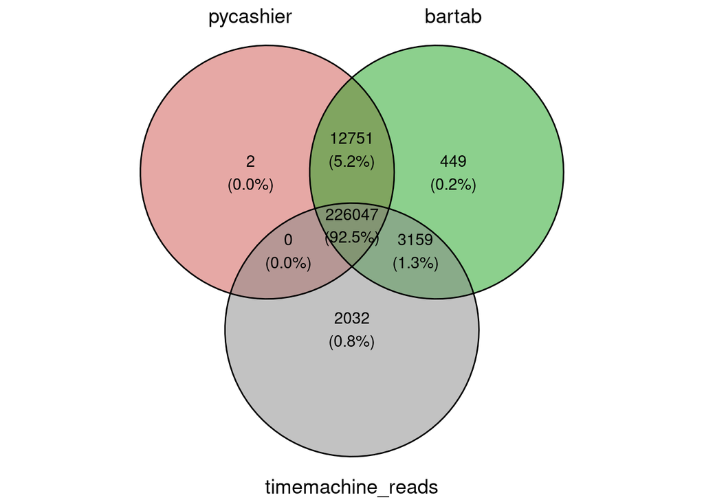

```r
ggsave(file.path(
  plots.dir,
  "venn_timemachine_reads_bartab_pycashier_0.001p.pdf"
))
ggvenn(
  x_filtered_.0001,
  columns = c("pycashier", "bartab", "timemachine_reads"),
  fill_color = c("#CD534CFF", "#1AA11DC1", "#868686FF"),
  stroke_size = 0.5,
  set_name_size = 5
)
```

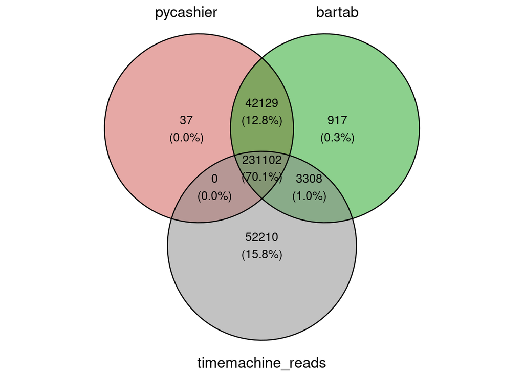

```r
ggsave(file.path(
  plots.dir,
  "venn_timemachine_reads_bartab_pycashier_0.0001p.pdf"
))
ggvenn(
  x,
  columns = c("pycashier", "bartab", "timemachine_reads"),
  fill_color = c("#CD534CFF", "#1AA11DC1", "#868686FF"),
  stroke_size = 0.5,
  set_name_size = 5
)
```

```r
ggsave(file.path(plots.dir, "venn_timemachine_reads_bartab_pycashier.pdf"))
```

Check what percentage of barcodes detected by timemachine are also detected by BARtab/pycashier

```r
sum(x_filtered_.001[["timemachine_reads"]] %in% x_filtered_.001[["bartab"]]) / length(x_filtered_.001[["timemachine_reads"]])
```

```
## [1] 0.9947465
```

```r
sum(x_filtered_.001[["timemachine_reads"]] %in% x_filtered_.001[["pycashier"]]) / length(x_filtered_.001[["timemachine_reads"]])
```

```
## [1] 0.9830855
```

### Correlation of barcode quantification

Data wrangling: combine results from timemachine (read count), pycashier and BARtab.

```r
bartab_long <- bartab_results_collapsed$counts %>%
  as.data.frame() %>%
  rownames_to_column("barcode") %>%
  pivot_longer(cols = -barcode,
               values_to = "count",
               names_to = "sample") %>%
  mutate(dataset = "bartab")

pycashier_long <- pycashier_results_collapsed$counts %>%
  as.data.frame() %>%
  rownames_to_column("barcode") %>%
  pivot_longer(cols = -barcode,
               values_to = "count",
               names_to = "sample") %>%
  mutate(dataset = "pycashier")

timemachine_reads_long <- timemachine_reads_results$counts %>%
  as.data.frame() %>%
  rownames_to_column("barcode") %>%
  pivot_longer(cols = -barcode,
               values_to = "count",
               names_to = "sample") %>%
  mutate(dataset = "timemachine_reads")

timemachine_umis_long <- timemachine_umis_results$counts %>%
  as.data.frame() %>%
  rownames_to_column("barcode") %>%
  pivot_longer(cols = -barcode,
               values_to = "count",
               names_to = "sample") %>%
  mutate(dataset = "timemachine_umis")

results_merged_long <- rbind(timemachine_reads_long, timemachine_umis_long, pycashier_long, bartab_long)

results_merged_wideish <- results_merged_long %>%
  pivot_wider(
    id_cols = c(barcode, sample),
    names_from = dataset,
    values_from = count
  ) %>%
  mutate(barcode_length = str_length(barcode))

results_merged_wideish[is.na(results_merged_wideish)] <- 0
```

Save intermediate results.

```r
write.csv(
  results_merged_wideish,
  file.path(results.dir, "bartab_timemachine_pycashier_counts_mean.csv")
)
results_merged_wideish <-
  read.csv(
    file.path(results.dir, "bartab_timemachine_pycashier_counts_mean.csv"),
    row.names = 1
  )
```

Calculate spearman and pearson correlation between timemachine (read count) and BARtab results.

```r
sp_cor_ls <- c()
ps_cor_ls <- c()

for (sample in colnames(timemachine_reads_results)) {
  bc_counts_merged <- results_merged_wideish %>%
    filter(sample == !!sample) %>%
    # do not conside (0|0) points for correlation since samples have different barcode sets
    filter(!(bartab == 0 & timemachine_reads == 0))

  sp_c <-
    cor(bc_counts_merged$bartab,
        bc_counts_merged$timemachine_reads,
        method = "spearman")
  sp_cor_ls <- c(sp_cor_ls, sp_c)
  ps_c <-
    cor(bc_counts_merged$bartab,
        bc_counts_merged$timemachine_reads,
        method = "pearson")
  ps_cor_ls <- c(ps_cor_ls, ps_c)
}
```

Convert to data frame.

```r
cor_results <-
  data.frame(list(
    "spearman" = sp_cor_ls,
    "pearson" = ps_cor_ls,
    "sample" = colnames(timemachine_reads_results)
  ))

cor_results <- cor_results %>%
  pivot_longer(cols = c(spearman, pearson), names_to = "method")
```

```r
write.csv(
  cor_results,
  file.path(
    results.dir,
    "bartab_mean_timemachine_read_count_correlation.csv"
  )
)
cor_results <-
  read.csv(
    file.path(
      results.dir,
      "bartab_mean_timemachine_read_count_correlation.csv"
    ),
    row.names = 1
  )
```

Check minimum and maximum correlation.

```r
cor_results %>%
  group_by(method) %>%
  summarise(min(value), max(value))
```

```
## # A tibble: 2 × 3
##   method   `min(value)` `max(value)`
##   <chr>           <dbl>        <dbl>
## 1 pearson         0.998        1.00
## 2 spearman        0.966        0.990
```

Plot box plot of correlation between time machine (read count) and BARtab barcode quantification.

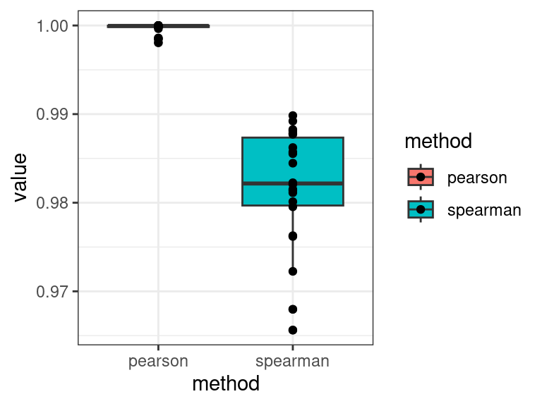

```r
ggplot(cor_results, aes(x = method, y = value, fill = method)) +
  geom_boxplot() +
  geom_point() +
  theme_bw()
```

```r
# ggsave(file.path(plots.dir, "violin_pearson_spearman_correlation.pdf"))
ggsave(file.path(plots.dir, "boxplot_pearson_spearman_correlation_timemachine_reads_bartab.pdf"))
```

Add spearman correlation value to facet label.

```r
cor_labels <- cor_results %>%
  filter(method == "spearman") %>%
  mutate(label = paste0(sample, " (r=", round(value, 2), ")")) %>%
  pull(label)

names(cor_labels) <- cor_results %>%
  filter(method == "spearman") %>% pull(sample)
```

Visualize correlation between BARtab and time machine for all samples in faceted point plot.

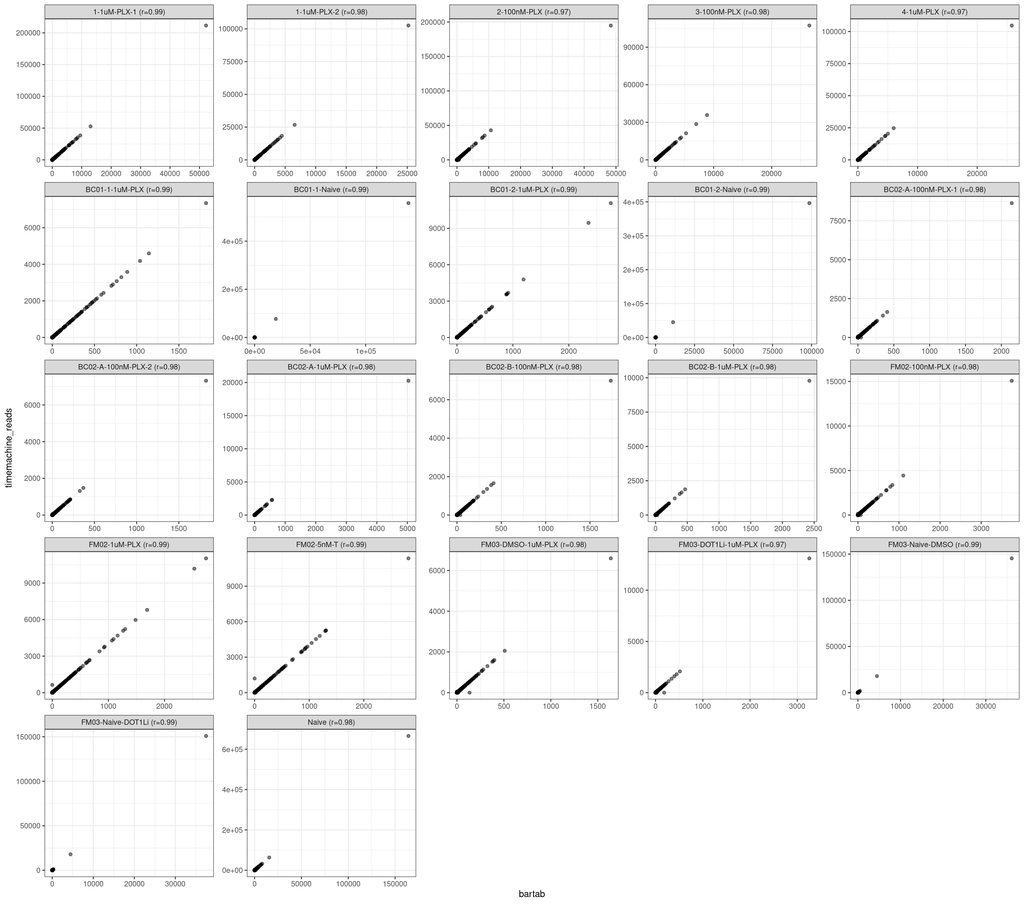

```r
results_merged_wideish %>%
  filter(bartab != 0 | timemachine_reads != 0) %>%
  ggplot(aes(x = bartab, y = timemachine_reads)) +
  geom_point(alpha = 0.5) +
  facet_wrap(
    ~ sample,
    ncol = 5,
    scales = "free",
    labeller = labeller(sample = cor_labels)
  ) +
  theme_bw()
```

```r
ggsave(file.path(plots.dir, "timemachine_reads_bartab_spearman_point_facet.pdf"))
```

Comparing UMI and read counts from timemachine re-analysis.

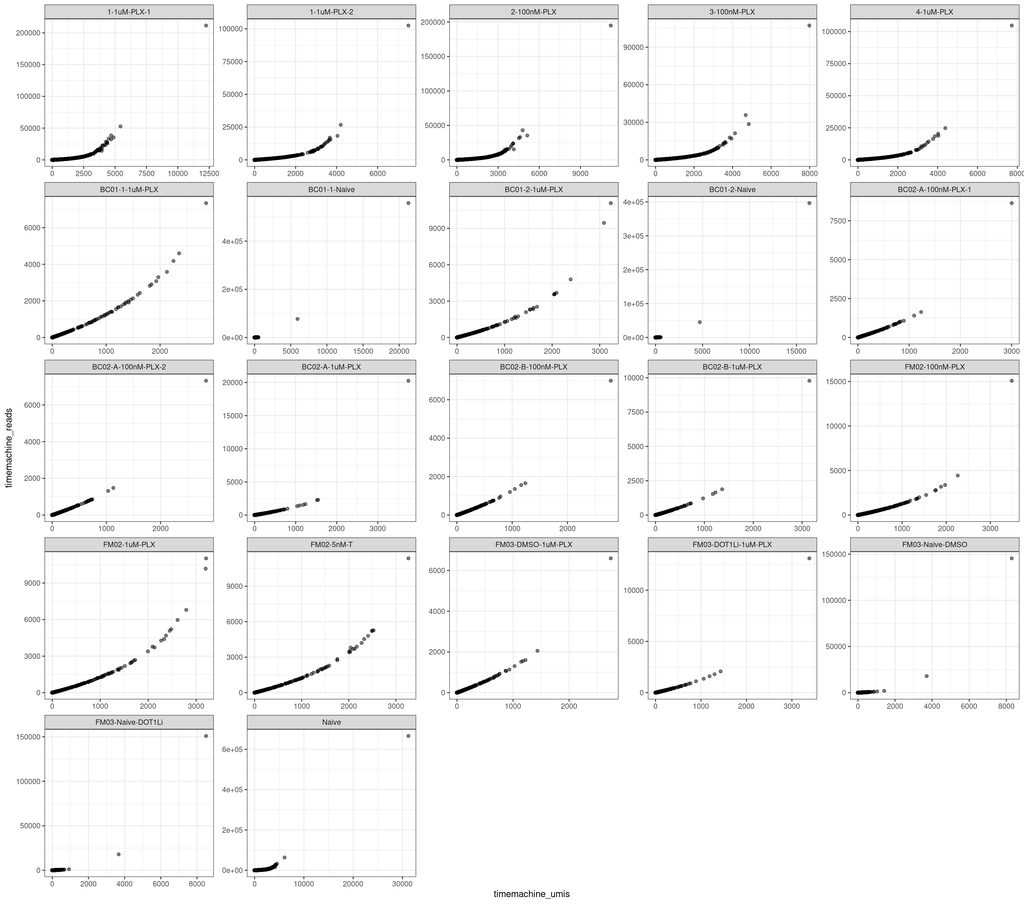

```r
results_merged_wideish %>%
  filter(timemachine_umis != 0 | timemachine_reads != 0) %>%
  ggplot(aes(x = timemachine_umis, y = timemachine_reads)) +
  geom_point(alpha = 0.5) +
  facet_wrap(
    ~ sample,
    ncol = 5,
    scales = "free"
  ) +
  theme_bw()
```

```r
ggsave(file.path(plots.dir, "timemachine_reads_umis_point_facet.pdf"))
```